# Spain votes again

## After the Urda crash the minister resigned within six days; after the DANA floods, Valencia’s president took a year

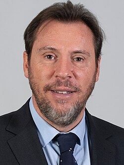

**Óscar Puente**  
PSOE · Transport minister

**28 Oct 2026** · Urda (Toledo): two trains collide, at least 69 dead

**3 Nov 2026** · resigns and leaves the PSOE lists

6 days

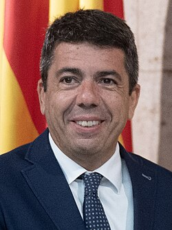

**Carlos Mazón**  
PP · President of the Valencian region

**29 Oct 2024** · DANA floods: 229 dead in Valencia province

**3 Nov 2025** · resigns, but keeps his seat in the regional parliament

370 days

Source: Xataka, eldiario.es, El Español, RTVC (Oct–Nov 2026); El Independiente, Ara (Nov 2025).

Photos: Wikimedia Commons — La Moncloa (attribution); EC Audiovisual Service (CC BY 4.0).

4 · The whole chronology

## No single crisis did it: seventeen months of accumulated shocks

CAMPAIGN · 55 DAYS

**Jun 2025**Cerdán resigns

**Oct 2025**Junts breaks with PSOE

**18 Jan**Adamuz crash: 45+ dead

**22 Jun**Ábalos: 24 years

**30 Jul**Ceuta crisis

**23 Sep**Maricarmen evicted

**2 Oct**Housing decrees defeated

**5 Oct**Snap election called

**28 Oct**Urda crash: 69+ dead

**3 Nov**Puente resigns

**11 Nov**Housing general strike

**19 Nov**Sánchez–Feijóo debate

CorruptionCatalonia / coalitionRailMigrationHousingElection & campaign Evenly spaced, not to scale

Source: As on previous slides; full list in the backup chronology.

Part 5

# The debates

A head-to-head, eight spokespeople, and tonight four leaders.

05

How Spaniards vote

Dictatorship to fragmentation

2023 and the players

The road to the snap election

The debates

5 · The debates

## Three debates: a head-to-head, the spokespeople, and tonight the leaders

Thu 19 Nov · Sánchez vs Feijóo

**Corruption dominated.** Snap polls gave it to Feijóo; Sánchez apologised to the rail victims’ families.

Mon 23 Nov · RTVE · eight spokespeople

PPPSOEVoxFrente AmplioERCJuntsEH BilduPNV

### Tonight, as we finish

The four-way debate at the Academia de Televisión

Pedro Sánchez  
PSOE

[figure not shown]

Alberto Núñez Feijóo  
PP

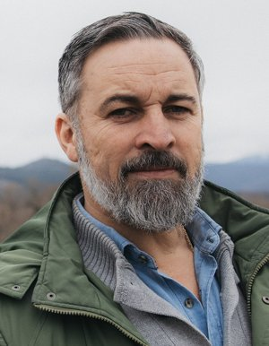

Santiago Abascal  
Vox

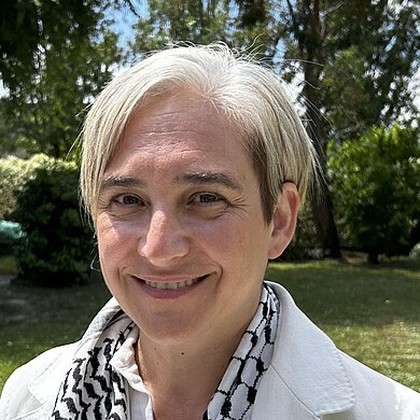

Ada Colau  
Frente Amplio

Source: El Español/SocioMétrica (20 Nov), Demócrata, Ara (19–20 Nov); 40dB via Electomanía, Demócrata; Articulo14, Diario de León (23 Nov); Estrella Digital. Portraits: Wikimedia Commons.

5 · Tonight’s question: pacts

## In the regions, the PP won four elections in a row, and needed Vox every time

Feijóo, 23 Nov: open to a pact with Vox after Sunday, but *“nobody can sign illegal agreements”*. What that looks like, region by region:

**Extremadura**  
21 Dec 2025

**PP 29** / 33 needed  
**Vox 11** (was 5)

Vox in government (Apr 2026)

**Aragón**  
8 Feb 2026

**PP 26** / 34 needed  
**Vox 14** (was 7)

PP–Vox government

**Castilla y León**  
15 Mar 2026

**PP 33** / 42 needed  
**Vox 14** (was 13)

PP–Vox pact (Sep 2026)

**Andalucía**  
17 May 2026

**PP 53** / 55 needed  
**Vox 15** (was 14)

Vox vice-presidency (Jul 2026)

PP seatsVox seats | = absolute majority

**Déjà vu:** PP and Vox governed five regions together after 2023; Vox walked out in July 2024 over the relocation of migrant children. In 2026 they are back, with Vox’s ‘national priority’ written into the pacts.

Source: Extremadura: El Independiente, RTVC (21 Dec 2025); Aragón: RTVC, El Salto (8 Feb 2026); Castilla y León: Wikipedia, Moncloa.com (Sep 2026); Andalucía: Euronews, El Salto, Diario de León (May–Jul 2026); Feijóo: El Debate (23 Nov), Moncloa.com (19 Nov).

Sunday 29 November

# What to watch on Sunday

1

**Another Sánchez comeback?**  
As in 2023, against the polls

2

**Hope, fear or punishment?**  
What moves voters after this autumn

3

**Can PP + Vox reach 176?**  
If not, another patchwork of partners, like Sánchez's 179 in 2023

Sources

## Sources

- Transition: Huntington (1991) The Third Wave; Congreso de los Diputados · Institutions: Spanish Constitution arts. 56, 64, 66–69, 99
- Elections and vote shares 1977–2023: Ministry of the Interior (via Wikipedia, ‘Elections in Spain’) · Electoral law: LOREG 5/1985 · NL: Kiesraad
- 15-M: Eurostat youth unemployment 2011; El País, RTVE archives · 2023 results and investitures: Ministry of the Interior; Congreso
- Cerdán: Euronews, Ara, RTVC (Jun 2025) · Junts: Ara, El Independiente (Oct 2025) · Adamuz: CIAF via Infobae, Xataka, RTVC · Ábalos: Poder Judicial, Euronews
- Ceuta: Real Instituto Elcano, Euronews · Maricarmen: Ara, Euronews, Diario de León, Primicias · Decrees: El Salto, Ara, Euronews, Law & Trends · Call: Articulo14
- Urda, Puente: Xataka, eldiario.es, El Español · Mazón/DANA: El Independiente, Ara (Nov 2025) · Strike: El Salto · Puigdemont: La Nación, El Boletín (Nov 2026)
- Debates: SocioMétrica/El Español, Demócrata, Ara, Articulo14, Diario de León, Estrella Digital · 40dB: Electomanía, Demócrata
- Posters: 29n.voto · Photos: Wikimedia Commons (licences on each slide)

Backup

# Backup slides

For the discussion

Backup 1

## Catalonia in one page, 2010–2026

**2010**Constitutional Court cuts the Catalan Statute

**2012–15**Mass independence marches; 2014 informal vote

**Oct 2017**Referendum, declaration, Article 155

**2019**Supreme Court sentences the leaders

**2021**Government pardons them

**2023–24**Amnesty in exchange for the investiture

**May 2024**Socialist Salvador Illa wins Catalonia

**Oct 2025**Junts breaks with the PSOE (87% of members)

**Oct 2026**ERC and Podemos run together

**Nov 2026**Last case closed; Puigdemont to return 12 Dec

Source: Constitutional Court (2010); Generalitat; Congreso de los Diputados; Ara (2025); orain.eus, infoLibre (Oct 2026); La Nación, El Boletín (Nov 2026).

Backup 2

## Detailed chronology, with sources

| Date | Event | Sources |
| --- | --- | --- |
| 12 Jun 2025 | Santos Cerdán resigns after UCO police report | Euronews; RTVC |
| 27–30 Oct 2025 | Junts ends deals with PSOE (members: 87%) | Ara; El Independiente |
| 18 Jan 2026 | Adamuz: two high-speed trains collide; 45–46 dead | Xataka; RTVC; Infobae |
| 22 Jun 2026 | Supreme Court sentences Ábalos to 24 years, Koldo to ~19 | Poder Judicial; Euronews |
| 30–31 Jul 2026 | Mass entry into Ceuta | Elcano; Euronews |
| 23 Sep 2026 | Maricarmen (87) evicted in Retiro, Madrid | Ara; Diario de León; Euronews |
| 2 Oct 2026 | Congress rejects the housing decrees (178–172) | El Salto; Ara |
| 5 Oct 2026 | Sánchez calls snap election for 29 Nov | Articulo14 |
| 7 Oct 2026 | Maricarmen dies in hospital | Primicias; Publimetro |
| 28 Oct 2026 | Urda (Toledo): two trains collide; at least 69 dead | Hola; Xataka |
| 3 Nov 2026 | Óscar Puente resigns, leaves PSOE lists | eldiario.es; El Español |
| 5 Nov 2026 | Koldo says PP lawyer offered €1M; PP denies | RTVC; Demócrata |
| 11 Nov 2026 | General strike over housing and wages | El Salto |
| 12 Nov 2026 | Anti-eviction decree validated 35–34; rental decree falls | Euronews; Ara |
| 19 Nov 2026 | Sánchez–Feijóo debate; SocioMétrica 64–32 | El Español; Demócrata |
| 23 Nov 2026 | RTVE debate of eight spokespeople | Articulo14; Diario de León |